# lista2-adar-GeancarloBorgesCaruso

Geancarlo Borges Caruso 202010032

13/01/2022

## Exercícios

1. Crie um vetor com os valores de $e^{x}cos{x}$ para os valores de $x = (3, 3.1, 3.2, ..., 6$).

```r
(x <- seq(from = 3, to = 6, by = 0.1))
```

```
##  [1] 3.0 3.1 3.2 3.3 3.4 3.5 3.6 3.7 3.8 3.9 4.0 4.1 4.2 4.3 4.4 4.5 4.6 4.7 4.8
## [20] 4.9 5.0 5.1 5.2 5.3 5.4 5.5 5.6 5.7 5.8 5.9 6.0
```

```r
(vet <- exp(x) * cos(x))
```

```
##  [1] -19.884531 -22.178753 -24.490697 -26.773182 -28.969238 -31.011186
##  [7] -32.819775 -34.303360 -35.357194 -35.862834 -35.687732 -34.685042
## [13] -32.693695 -29.538816 -25.032529 -18.975233 -11.157417  -1.362099
## [19]  10.632038  25.046705  42.099201  61.996630  84.929067 111.061586
## [25] 140.525075 173.405776 209.733494 249.468441 292.486707 338.564378
## [31] 387.360340
```

2. Crie os seguintes vetores.
1. $(0.1^{3}\times0.2^{1},0.1^{6}\times0.2^{4},...,0.1^{36}\times0.2^{34})$

```r
x <- 0.1
y <- 0.2
(n <- seq(from = 3, to = 36, by = 3))
```

```
##  [1]  3  6  9 12 15 18 21 24 27 30 33 36
```

```r
(m <- seq(from = 1, to = 34, by = 3))
```

```
##  [1]  1  4  7 10 13 16 19 22 25 28 31 34
```

```r
c(round(vet <- (x^n) * (y^m), 36))
```

```
##  [1] 2.0000e-04 1.6000e-09 1.2800e-14 1.0240e-19 8.1920e-25 6.5536e-30
##  [7] 5.2000e-35 0.0000e+00 0.0000e+00 0.0000e+00 0.0000e+00 0.0000e+00
```

2. $(2, \frac{2^{2}}{2}, \frac{2^{3}}{3}, ..., \frac{2^{25}}{25})$

```r
n <- seq(from = 1, to = 25, by = 1)
c(round(x <- (2^n) / n, 0))
```

```
##  [1]       2       2       3       4       6      11      18      32      57
## [10]     102     186     341     630    1170    2185    4096    7710   14564
## [19]   27594   52429   99864  190650  364722  699051 1342177
```

3. Reproduza a criação do vetor dias da semana (`dds`) mostrado abaixo.

```
domingo segunda   terça  quarta  quinta   sexta  sábado
      1       2       3       4       5       6       7
```

```r
dds <- c(1, 2, 3, 4, 5, 6, 7)
semana <- c("domingo", "segunda", "terça", "quarta", "quinta", "sexta", "sábado")
names(dds) <- semana
dds
```

```
## domingo segunda   terça  quarta  quinta   sexta  sábado
##       1       2       3       4       5       6       7
```

4. Interprete o resultado da seguinte operação:

```r
dds_nums <- c(5L, 2L, 5L, 2L, 7L, 7L, 2L, 6L, 6L, 3L, 7L, 1L, 2L, 2L, 5L, 7L, 3L, 2L, 6L, 4L, 1L)
names(dds)[dds_nums]
```

```
##  [1] "quinta"  "segunda" "quinta"  "segunda" "sábado"  "sábado"  "segunda"
##  [8] "sexta"   "sexta"   "terça"   "sábado"  "domingo" "segunda" "segunda"
## [15] "quinta"  "sábado"  "terça"   "segunda" "sexta"   "quarta"  "domingo"
```

```r
class(names(dds)[dds_nums])
```

```
## [1] "character"
```

5. 1. Escreva o código necessário para determinar o vetor lógico indicando quais números são pares na sequência de valores 85, 79, 70, 6, 32, 8, 17, 93, 81, 76. b. Calcule o total de números ímpares.

```r
vetor <- c(85, 79, 70, 6, 32, 8, 17, 93, 81, 76)

par_impar <- c()
for (i in vetor) {
  if (i %% 2 == 0) {
    par_impar[i] <- "par"
  } else {
    par_impar[i] <- "impar"
  }
}

par_impar
```

```
##  [1] NA      NA      NA      NA      NA      "par"   NA      "par"   NA
## [10] NA      NA      NA      NA      NA      NA      NA      "impar" NA
## [19] NA      NA      NA      NA      NA      NA      NA      NA      NA
## [28] NA      NA      NA      NA      "par"   NA      NA      NA      NA
## [37] NA      NA      NA      NA      NA      NA      NA      NA      NA
## [46] NA      NA      NA      NA      NA      NA      NA      NA      NA
## [55] NA      NA      NA      NA      NA      NA      NA      NA      NA
## [64] NA      NA      NA      NA      NA      NA      "par"   NA      NA
## [73] NA      NA      NA      "par"   NA      NA      "impar" NA      "impar"
## [82] NA      NA      NA      "impar" NA      NA      NA      NA      NA
## [91] NA      NA      "impar"
```

6. Para um ano ser bissexto, ele deve ser:
- divísivel por 4 (a divisão é exata com resto igual a zero)
- não pode ser divisível por 100 (a divisão não é exata, ou seja, o resto é diferente de zero)
- pode ser que seja divisível por 400: caso seja divisível por 400, a divisão deve ser exata, deixando o resto igual a zero.

$\qquad$ Com os critérios definidos acima, construa o código para:

1. Verificar se os anos 1894, 1947, 1901, 1992, 1925, 2014, 1993, 1996, 1984, 1897, 2100, 2300 são bissextos.
2. Mostre quais anos são bissextos.
3. Usando o código para verificar se o ano é bissexto, gere um vetor nomeado `ndias` com o número de dias do ano para os anos do item (a).
4. Programe como obter o total de anos com 366 dias?

```r
library(lubridate)
(ano <- c(1894, 1947, 1901, 1992, 1925, 2014, 1993, 1996, 1984, 1897, 2100, 2300))
```

```
##  [1] 1894 1947 1901 1992 1925 2014 1993 1996 1984 1897 2100 2300
```

```r
leap_year(ano)
```

```
##  [1] FALSE FALSE FALSE  TRUE FALSE FALSE FALSE  TRUE  TRUE FALSE FALSE FALSE
```

7. Quais códigos para gerar os seguintes dados:

[output not shown]

```r
a=seq(from = -30, to = 0, by = 30)
b=seq(from = 5, to = 30, by = 5)
res = c(a,b)
res
```

```
## [1] -30   0   5  10  15  20  25  30
```

```
[1] 1.0 0.8 0.6 0.4 0.2 0.0
```

```r
seq(from = 1, to = 0, by = -0.2)
```

```
## [1] 1.0 0.8 0.6 0.4 0.2 0.0
```

```
[1] -3.1415927 -2.4434610 -1.7453293 -1.0471976 -0.3490659  0.3490659
[7]  1.0471976  1.7453293  2.4434610  3.1415927
```

```r
# -2.4434610 - (-3.1415927)
# 3.1415927 - 2.4434610

seq(from = -3.1415927, to = 3.1415927, by = 0.6981317)
```

```
##  [1] -3.1415927 -2.4434610 -1.7453293 -1.0471976 -0.3490659  0.3490658
##  [7]  1.0471975  1.7453292  2.4434609  3.1415926
```

```
[1] -1 -1  0  0  0  1  1  1  1  2  2  2  2  2  3  3  3  3  3  3  4  4  4
[24]  4  4  4  4  5  5  5  5  5  5  5  5
```

```r
rep(x = -1:5, times = 2:8)
```

```
##  [1] -1 -1  0  0  0  1  1  1  1  2  2  2  2  2  3  3  3  3  3  3  4  4  4  4  4
## [26]  4  4  5  5  5  5  5  5  5  5
```

```
[1] 5 5 5 5 5 4 4 4 4 3 3 3 2 2 1 2 2 3 3 3 4 4 4 4 5 5 5 5 5
```

```r
a <- rep(x = 5:1, times = 5:1)
b <- rep(x = 2:5, times = 2:5)
res <- c(a, b)
res
```

```
##  [1] 5 5 5 5 5 4 4 4 4 3 3 3 2 2 1 2 2 3 3 3 4 4 4 4 5 5 5 5 5
```

8. Usando o mesmo código para solução em todos os itens abaixo, obtenha as seguintes sequências usando os vetores fornecidos.
1. v3 = (11, 0.25, 7, 2)

```
[1] 1 2 3 4
```

2. v2 = (11, 0.25)

```
[1] 1 2
```

3. v1 = (11)

```
[1] 1
```

4. v0 = ()
9. Considere os seguintes dados horários de temperatura do ar ($T_{ar}$) registrados em duas estações meteorológicas, entre as 0 e 23 horas de um dado dia.

```r
tar_est1 <- c(
  14.92, 14.61, 14.32, 14.07, 13.84, 13.65, 13.56, 13.97, 15.08,
  16.5, 17.88, 19.08, 20.02, 20.66, 21.01, 21.05, 20.76, 20.05,
  18.77, 17.51, 16.67, 16.11, 15.66, 15.27
)
tar_est2 <- c(
  13.13, 13.01, 12.93, 12.87, 12.82, 12.81, 13.2, 14.22, 15.77,
  17.49, 19.2, 20.57, 21.49, 22.01, 22.03, 21.71, 20.84, 18.77,
  16.54, 15.13, 14.34, 13.81, 13.49, 13.28
)
```

> Dica: Faça um gráfico para visualizar as temperaturas das duas estações. Isso facilitará a solução.

**a.** Determine a média diária da $T_{ar}$ das duas estações arrendondando para uma casa decimal. Salve a média de cada estação nas variáveis `tmed_est1` e `tmed_est2`.

**b**. Utilizando as variáveis do item anterior, verifique usando comparação lógica, em qual estação o ambiente é mais quente?

**c**. Obtenha a 3ª maior temperatura do dia em cada estação.

**d**. Calcule a amplitude térmica diária ($ATD = T_{max}-T_{min}$, onde $T_{max}$: temperatura máxima dária e $T_{min}$: temperatura mínima dária) das estações 1 e 2, arrendondando para uma casa decimal. Salve os resultados nas variaveis `atd_est1` e `atd_est2`.

**e**. Qual o horário de ocorrência das temperaturas máximas e mínimas em cada estação? Salve os resultados nas variáveis `hmax_est{i}` e `hmin_est{i}`, com $i = 1, 2$.

**f**. Quando `tar_est2` é maior que `tar_est1` qual a maior diferença absoluta de temperatura entre as duas estações?

**g**. Qual a hora correspondende a ocorrência daquela maior diferença absoluta de temperatura obtida no item anterior?

**h**. O horário do pôr do sol pode ser estimado a partir da $T_{ar}$. Para o período após o horário de ocorrência da $T_{max}$ determina-se em qual hora ocorre a maior queda de $T_{ar}$ em relação a hora anterior. Estime o horário do pôr do sol para as duas estações (`hps_est{i}`).

**i**. Em quais horas as temperaturas das duas estações estão mais próximas uma da outra, ou seja com menos de 0,5°C de diferença ?

**j**. Calcule a temperatura média diária usando os seguintes métodos para estação 2.

$T_{med_{1}} = (T_{max} + T_{min})/2$, salvando em uma variável `tar_met1`.

$T_{med_{2}} = (T_{max} + T_{min} + T_{9} + 2T_{21})/5$, salvando em uma variável `tar_met2`.

$T_{med_{3}} = (T_{7} + T_{14} + 2T_{21})/4$, salvando em uma variável `tar_met2`.

**k**.Compare este resultados com aqueles obtidos no item **a**. Qual é melhor?

10. Calcule a temperatura do ar horária usando o **modelo de onda** para representação do ciclo diário da temperatura do ar, descrito pelas seguintes equações:

$$\left\{\begin{matrix}
h_{T_{min}}\leq h < h_{T_{max}}, & T_{calc} = \bar{T} - A \, cos\left ( arg \right )\\demais\; horas, & T_{calc} = \bar{T} + A \, cos\left ( arg \right )\end{matrix}\right.$$

onde:

$$\bar{T} = \left ( \frac{T_{max} + T_{min}}{2} \right )$$

e

$$A =\left ( \frac{T_{max}-T_{min}}{2} \right )$$

O argumento do cosseno ($arg$) é definido por:

$$\left\{\begin{matrix}
h < h_{T_{min}}, & arg = \pi \left ( \frac{h+10}{10+h_{Tmin}} \right )\\
h_{T_{min}}\leq h < h_{T_{max}}, & arg = \pi \left ( \frac{h-h_{T_{min}}}{14-h_{T_{min}}} \right )\\
h > h_{T_{max}}, & arg = \pi\left ( \frac{14-h}{10+h_{Tmin}} \right )
\end{matrix}\right.$$

**a**. Aplique o método acima para estação 1 e 2 substituindo os valores de $T_{max}$, $T_{min}$, $h_{T_{max}}$, $h_{T_{max}}$, adequadamente.

**b**. Calcule o RMSE nos dois casos. $RMSE=\sqrt{\frac{1}{n}\sum_{i=1}^{n}\left(T_{calc}-T_{obs}\right )^{2}}$

**c**. Calcule a correlação ($r$) nos dois casos. A barra representa a média aritmética. Confira seu resultado com a saída da função `cor(tar_obs, tar_calc)`.

$$r=\frac{\sum_{i=1}^{n} (T_{obs}-\bar{T}_{obs})(T_{calc}-\bar{T}_{calc}))}{\sqrt{\sum_{i=1}^{n}(T_{obs}-\bar{T}_{obs})^{2}(T_{calc}-\bar{T}_{calc})^{2})}}$$

11. Os dados abaixo são de precipitação horária de um evento severo ocorrido em 03/12/2012 em Santa Maria-RS.

| **hora** | **prec** |
| --- | --- |
| 9 | 0.0 |
| 10 | 0.0 |
| 11 | 0.0 |
| 12 | 0.0 |
| 13 | 0.0 |
| 14 | 0.0 |
| 16 | 0.0 |
| 16 | 21.4 |
| 17 | 41.2 |
| 18 | 2.6 |
| 19 | 1.0 |
| 20 | 0.4 |
| 21 | 0.0 |

1. Como seria o código para determinar a soma cumulativa da precipitação horária? Salve o resultado em um vetor chamado `prec_acum`. Interprete o resultado de `c(NA, diff(prec_acum))`.
2. Mostre o código para encontrar o horário de ocorrência da precipitação máxima?
3. Mostre o código para obter a hora de início e fim do evento de precipitação severa. Qual foi a duração do evento?
4. Qual foi a precipitação total do evento? Quanto da precipitação total do evento, em %, ocorreu até às 17 h?
12. Considere o vetor `x` definido pelos números descritos abaixo. Mostre como encontrar o primeiro número positivo localizado após o último número negativo. Por exemplo, seja o vetor `z` definido pelos valores (11, 10, 15, 2, 6, -15, -10, -22, -8, 5, 7, 2, 12, 8, 4, 1, 3, -3, -1, 30, 14). Os valores selecionados seriam 5 e 30.
13. Considerando o vetor `prec` com valores de precipitação diária indicado abaixo. Escreva o código para resolver as seguintes tarefas.

```r
prec <- c(
  0, 0, 0, 0.8, 0, 0.01, 0.75, 0,
  0, 0, 0, 0.35, 0.08, 0, 0, 0, 0, 0.31, 0, 3.57, 12.17, 0, 0,
  0, 0.04, 3.16, 0, 0.95, 0.79, 0, 0, 0, 0, 0, 3.51, 0, 0, 0.16,
  0, 0, 8.16, 0.54, 4.39, 1.24, 0, 0, 0, 0, 0, 2.43, 0, 0, 0, 0,
  0, 7.18, 0, 0, 0.26, 0, 0, 0.28, 0, 0, 0.09, 0.38, 0, 0, 0, 0,
  0, 0, 0.51, 0, 0, 0, 0, 0, 0, 0.67, 0, 0, 0, 0, 0.15, 0, 0.82,
  0, 0, 0, 0, 0, 0, 0, 0, 0.37, 0, 0.58, 4.95, 0, 0, 0, 0, 0, 7.68,
  0, 0, 0.37, 0, 1.56, 0, 0, 0, 0.34, 0.48, 0, 4.21, 2.28, 4.3,
  0, 3.38, 0, 0, 0, 0, 7.28, 0, 4.89, 3.91, 0, 0, 0, 0, 0, 0, 2.93,
  0, 2.49, 0.77, 0, 2.9, 3.53, 0.83, 0, 0, 0, 0.94, 0.59, 0, 0,
  0, 0, 0.04, 0, 0.65, 0, 0, 0, 6.23, 0.09, 0, 0.66, 0, 0, 0, 4.42,
  0, 0, 0, 0.84, 0, 0, 0, 0, 0, 0.09, 0, 0, 0.08, 0, 0.66, 0, 0,
  0, 0.06, 0, 0, 0, 3.28, 0, 0.8, 5.69, 0.8, 0
)
```

1. Quantos dias ocorreram no intervalo 0 < prec < 0.25?
2. Substitua os valores de chuva registrados no intervalo 0 < prec < 0.25 por 0.
3. Crie um vetor denominado `prec01` indicando o estado da precipitação (chuvoso = 1, seco = 0) baseado no limiar de 0.25 mm para detecção de chuva pelo pluviômetro.
4. Qual a probabilidade de chuva dessa série de precipitação diária?
5. Qual a probabilidade de chover dois dias consecutivos (`p11`)? Calcule a probabilidade de chover em qualquer um de dois dias consecutivos (`p01 + p10`)?
6. Determine a duração de cada evento chuvoso (número de dias consecutivos).

O resultado esperado é um vetor que identifique o evento e sua duração.

```r
duracao <- c(evento1 = 1, evento2 = 1, evento3 = 1, evento4 = 1, evento5 = 2,
evento6 = 1, evento7 = 2, evento8 = 1, evento9 = 4, evento10 = 1,
evento11 = 1, evento12 = 1, evento13 = 1, evento14 = 1, evento15 = 1,
evento16 = 1, evento17 = 1, evento18 = 1, evento19 = 2, evento20 = 1,
evento21 = 1, evento22 = 1, evento23 = 2, evento24 = 3, evento25 = 1,
evento26 = 1, evento27 = 2, evento28 = 1, evento29 = 2, evento30 = 3,
evento31 = 2, evento32 = 1, evento33 = 1, evento34 = 1, evento35 = 1,
evento36 = 1, evento37 = 1, evento38 = 1, evento39 = 3)
```

```r
duracao
```

```
##  evento1  evento2  evento3  evento4  evento5  evento6  evento7  evento8
##        1        1        1        1        2        1        2        1
##  evento9 evento10 evento11 evento12 evento13 evento14 evento15 evento16
##        4        1        1        1        1        1        1        1
## evento17 evento18 evento19 evento20 evento21 evento22 evento23 evento24
##        1        1        2        1        1        1        2        3
## evento25 evento26 evento27 evento28 evento29 evento30 evento31 evento32
##        1        1        2        1        2        3        2        1
## evento33 evento34 evento35 evento36 evento37 evento38 evento39
##        1        1        1        1        1        1        3
```

14. Dado o vetor `dados` mostrado abaixo.

```r
dados <- c(
  NA, NA, 27L, 7L, 4L, 0L, 26L, 15L, 25L, NA, NA, NA, NA, 6L,
  29L, 18L, 17L, 23L, 20L, 1L, 30L, 13L, NA, NA, NA, NA, NA, NA,
  NA, 19L
)
```

1. Como você pode codificar a obtenção de um vetor com zeros nos valores válidos e com números sequenciais dentro das falhas?
2. Como a partir do vetor resultante do item anterior você pode obter um vetor cujo os valores dentro das falhas indique a ordem de ocorrência da falha.
3. Qual o código para determinar o tamanho de cada falha?
4. Como determinar o tamanho da maior falha?
15. Para os valores de velocidade ($V_h$) e a direção do vento ($\theta$) (na convenção meteorológica):

$V_h$ = 10, 10, 10, 10, 14.142, 14.142, 14.142, 14.142, 0

$\theta$ = 270, 180, 360, 90, 225, 315, 135, 45, 0

1. Determine as componentes zonal e meridional do vento.

   $$u=-V_{h}\cdot sin(\theta_{rad})$$
   $$v=-V_{h}\cdot cos(\theta_{rad})$$
2. Faça os cálculos necessários para reconstruir $V_h$ e $\theta$, a partir de $u$ e $v$ determinados no item **a**. Por convenção, a direção do vento $\theta$ em condições calmas ($V_h$ < 0.5 m s<sup>-1</sup>) é assumida como 0°.

$$V_{h}=\sqrt{(u^2+v^2)}$$
$$\theta_{mat}={\rm atan2}(-u, -v)\cdot\frac{180}{\pi}$$
$$\theta=\left\{\begin{matrix} \theta_{mat} + 360 & se & \theta_{mat} < 0 \\ 0 & se & u = 0,\: v = 0 \: \: ou \: \: V_{h} < 0.5\\ \end{matrix}\right.$$

A tabela abaixo apresenta o resultado esperado para as variáveis derivadas.

[output not shown]

> Dica: ver figura abaixo.

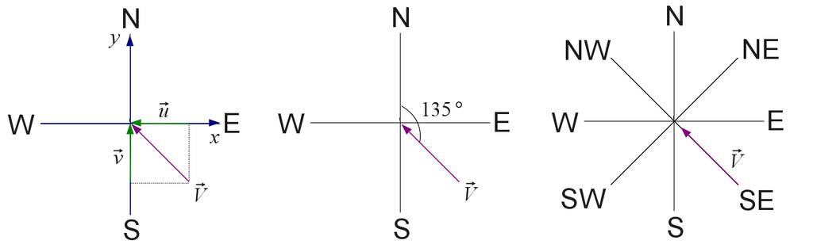

16. Para as séries de `prec_obs` e `prec_sim` calcule:
1. A proporção corretamente prevista $PC=\frac{wc+dc}{n}$
2. O índice de sucesso crítico $CSI=\frac{wc}{wc+wi+di}$.

Onde $wc$ e $dc$ são as previsões corretas de dias úmidos ($prec > 0.25$ mm dia<sup>-1</sup>) e secos respectivamente, $wi$ e $di$ são as previsões incorretas de dias úmidos e secos respectivamente. $n$ é o n° total de previsões.

```r
prec_obs <- c(
  0, 0, 0, 0.5, 1, 6, 9, 0.2, 1, 0, 0, 0.25,
  10, 15, 8, 3, 0, 0, 0, 0, 0, 0, 0.25, 0,
  0, 0, 1, 5, 0, 20, 0, 0, 0, 0, 1, 1,
  0, 2, 12, 1, 0, 0, 0, 0, 0, 0, 5, 5
)
prec_sim <- c(
  0, 0.2, 0.1, 0, 0, 3, 1, 1, 1, 1, 0, 3,
  0, 10, 4, 1, 0.3, 0.5, 0.5, 0.5, 0.5, 0, 0.25, 0.25,
  0.25, 0, 0.5, 3, 0, 5, 0, 0, 0, 0, 0.5, 0,
  0.25, 0.2, 0, 0.2, 0, 0, 0, 0, 1, 2, 1, 0
)
```

17. Escreva o código para calcular as estatísticas abaixo, entre os vetores de valores observados (`obs`) e previstos (`prev`) por um dado modelo atmosférico, em um dado local.
1. O Viés relativo (%) [^1].

$$PBIAS = 100\frac{\sum_{i=1}^{n}(Prev_{i}-Obs_{i})}{\sum_{i=1}^{n}(Obs_{i})}$$
.

2. Coeficente de eficiência de Nash-Sutcliffe (NSE) [^2].

$$NSE=1-\frac{\sum_{i=1}^{n} (Obs_{i}-Sim_{i})^{2}}{\sum_{i = 1}^{n} (Obs_{i}-\bar{Obs}_{i})^{2}}$$

```r
v_obs <- c(
  -0.49, 0.27, -0.48, 0.8, -1, 0.1, -1.16,
  0.58, -1.6, -0.31, 0.45, -0.98, 0.19, 0.73,
  -0.49, -0.04, -0.11, 0.46, 2.02, -1.05
)
v_prev <- c(
  NA, -0.49, 0.27, -0.48, 0.8, -1, 0.1, -1.16,
  0.58, -1.6, -0.31, 0.45, -0.98, 0.19, 0.73,
  -0.49, -0.04, -0.11, 0.46, 2.02
)
```

[^1]: Mede a tendência média dos valores previstos (ou simulados) em serem maiores (superestimativa) ou menores (subestiva) que os observados. O valor ótimo é 0, menores valores indicam melhor desempenho. Valores positivos indicam tendência de superestimativa e negativos de subestimativa
[^2]: NSE é uma estatística normalizada que que determina a magnitude relativa da variância residual (ruído) comparada a variância dos dados medidos (informação). NSE varia de -Inf a 1. Essencialmente, quanto mais próximo a 1, melhor o modelo